# Take-Home Final Exam

Computation for Data Analysis

Due: Monday, 11 May 2020 by 11:59 pm

Name: Vishal Vaidhyanathan Andrew ID: vvaidhya

#Instructions

- You must work alone.
- Submit your knitted HTML or pdf file to Canvas by **Monday, 11 May 2020 by 11:59 pm**. There are no grace days.
- For full credit on each question, make sure you follow exactly what is asked and answer each prompt. The total is 100 points.
- You may only ask clarification questions on Piazza; you may not ask for help unless you have problems loading data files. This is final project not a lab.
- Do not cheat. It will end poorly for everyone.

#Style

- use column names rather numerical indexes
- use informative variables names
- use comments to make it clear what you are attempting to do
- keep your code as simple as possible
- determine answers programmatically instead of manually

# Prostate cancer data set

Let’s return to the prostate cancer data set that we looked at in Week 3 (taken from the book [The Elements of Statistical Learning](http://statweb.stanford.edu/~hastie/ElemStatLearn/)). Recall, there are 9 variables measured on these 97 men:

1. `lcavol`: log cancer volume
2. `lweight`: log prostate weight
3. `age`: age of patient
4. `lbph`: log of the amount of benign prostatic hyperplasia
5. `svi`: seminal vesicle invasion
6. `lcp`: log of capsular penetration
7. `gleason`: Gleason score
8. `pgg45`: percent of Gleason scores 4 or 5
9. `lpsa`: log PSA score

Download the `pros_dat.txt` file from the Week 3 of the course canvas website. The following loads the data set into your R session, and stores it as a data frame `pros.dat`:

```r
pros.dat = read.table("pros_dat.txt")
```

**1a (3 pts)** Display its dimensions and the first 3 rows. Then display all the column names except for column 5. Finally display the column name for column 5.

```r
#Displaying Dimensions and the first three rows
dimension <- dim(pros.dat)
print(dimension)
```

```
## [1] 97  9
```

```r
print(pros.dat[1:3,])
```

```
##       lcavol  lweight age      lbph svi       lcp gleason pgg45       lpsa
## 1 -0.5798185 2.769459  50 -1.386294   0 -1.386294       6     0 -0.4307829
## 2 -0.9942523 3.319626  58 -1.386294   0 -1.386294       6     0 -0.1625189
## 3 -0.5108256 2.691243  74 -1.386294   0 -1.386294       7    20 -0.1625189
```

```r
#Displaying all column Names except column 5 (svi) and then name of column 5
names(pros.dat)[-5]
```

```
## [1] "lcavol"  "lweight" "age"     "lbph"    "lcp"     "gleason" "pgg45"
## [8] "lpsa"
```

```r
names(pros.dat)[5]
```

```
## [1] "svi"
```

**1b (3 pts)** Calculate the mean of each variable. Also, calculate the standard deviation of each variable. Each should require just one line of code. Display your results.

```r
cat("Means :\n")
```

```
## Means :
```

```r
# Mean of each variable in one line
apply(pros.dat,2,FUN = mean)
```

```
##     lcavol    lweight        age       lbph        svi        lcp    gleason
##  1.3500096  3.6289427 63.8659794  0.1003556  0.2164948 -0.1793656  6.7525773
##      pgg45       lpsa
## 24.3814433  2.4783869
```

```r
cat("SDs :\n")
```

```
## SDs :
```

```r
#Standard Deviation of each variable in one line
apply(pros.dat,2,FUN = sd)
```

```
##     lcavol    lweight        age       lbph        svi        lcp    gleason
##  1.1786249  0.4284112  7.4451171  1.4508066  0.4139949  1.3982496  0.7221341
##      pgg45       lpsa
## 28.2040346  1.1543291
```

**1c (6 pts)** Now create plot for each variable against SVI. Using a loop, plot each variable, excluding SVI, on the y-axis with SVI on the x-axis. Label the x-axis and y-axis in your plots appropriately. For full credit, use column names not numerical indices in your code.

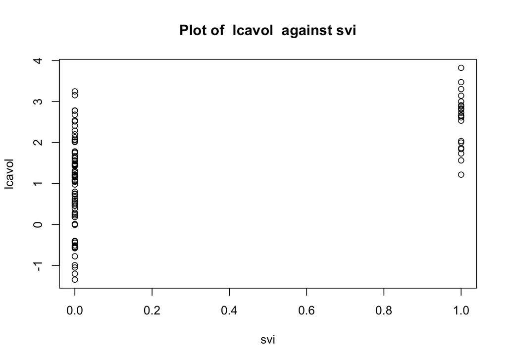

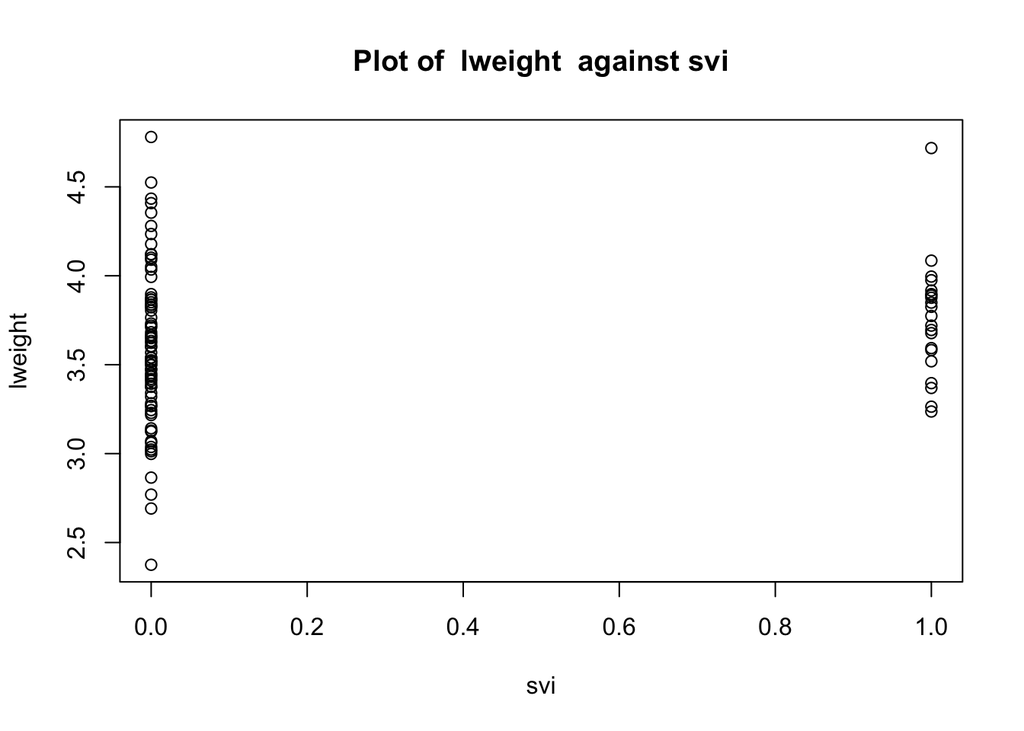

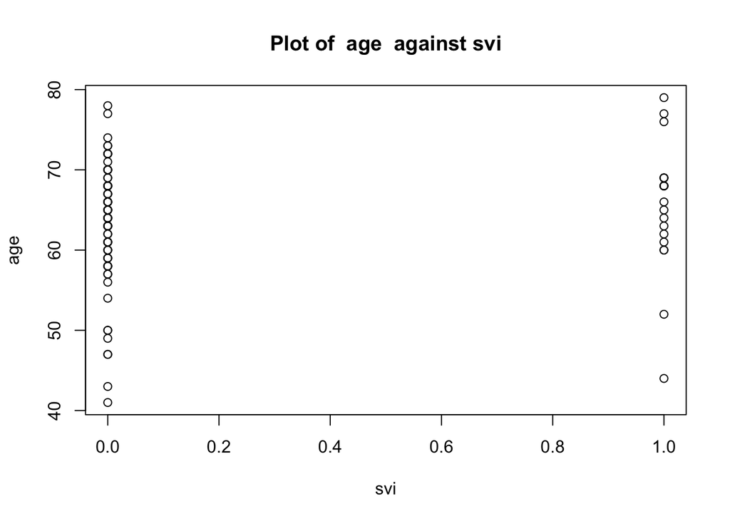

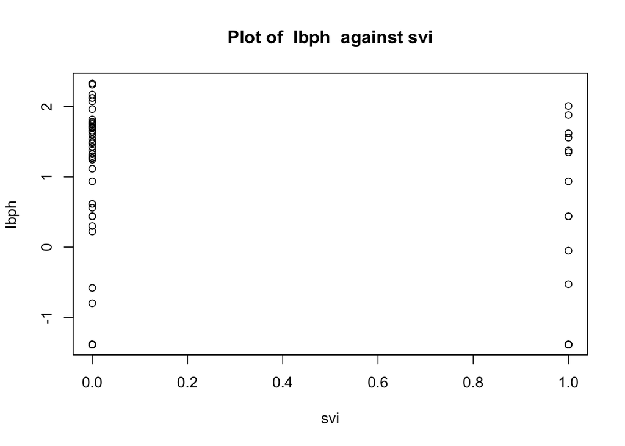

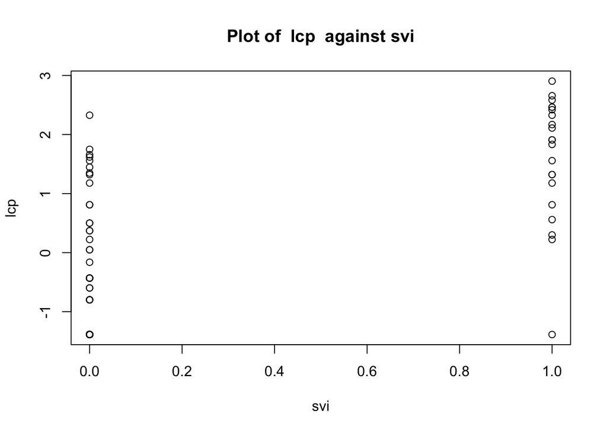

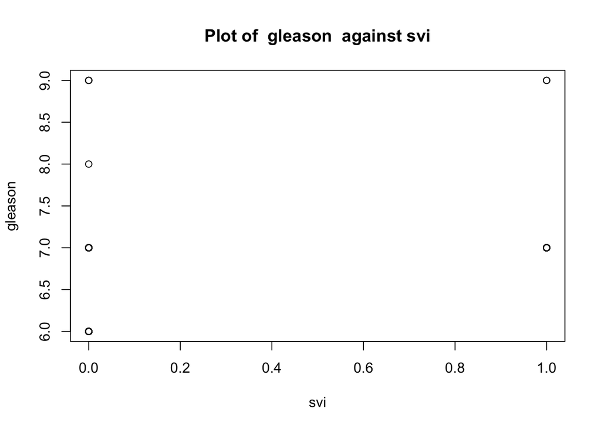

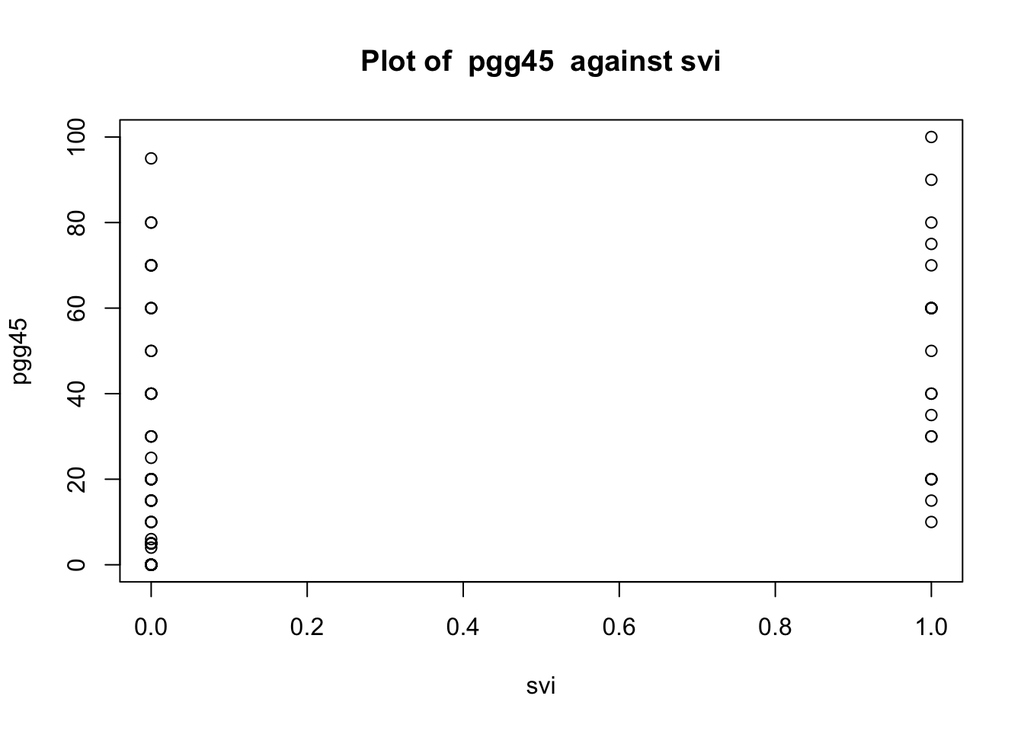

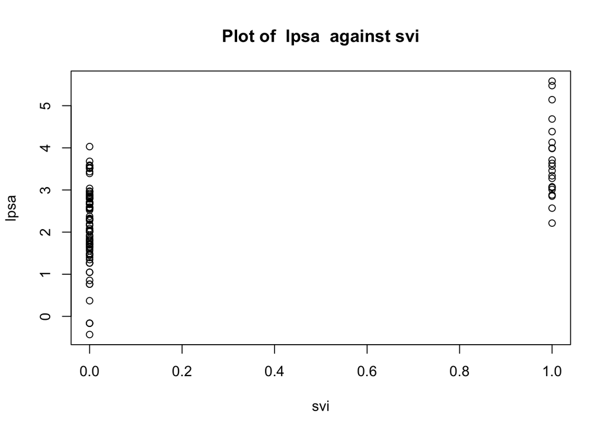

```r
#Iterating over each column (except svi) to plot against svi
for(i in names(pros.dat)[which(names(pros.dat) != "svi")]){
  plot(pros.dat[["svi"]],pros.dat[[i]], xlab = "svi", ylab = i,
       main = paste("Plot of ",i," against svi"))
}
```

**1d (10 pts)** Create a pair of overlapping histogram density plots of the `lcavol` variable for the SVI (value 1) and non-SVI (value 0) groups. Use 20 bars over the full range of `lcavol` values. Do this programmatically, not manually. Color the two groups of bars two different colors, one of them a transparent color. Add an estimated density line for each group. Provide labels and a legend as appropriate.

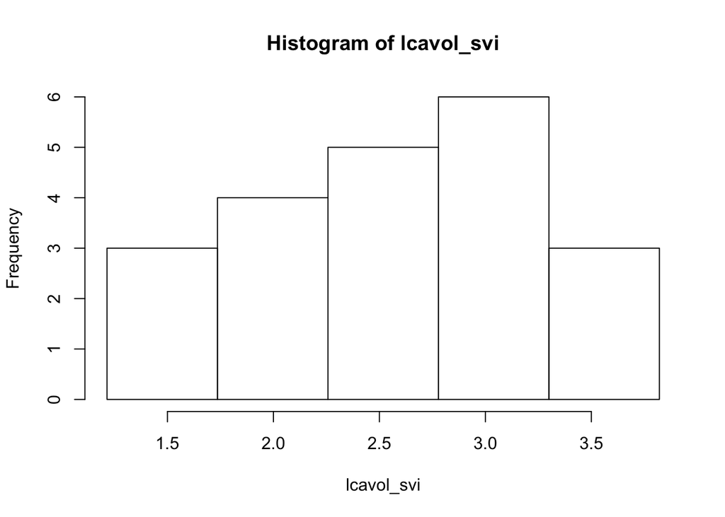

```r
#identifying the two required data
lcavol_svi <- pros.dat$lcavol[which(pros.dat$svi == 1)] #With SVI
lcavol_no_svi <- pros.dat$lcavol[which(pros.dat$svi == 0)] #Without SVI

#calculating bin-split for each variable to get 20 bins overall proportionally
#no of breaks
breaks_no.svi <- as.integer(length(lcavol_no_svi)/length(pros.dat$lcavol) * 20)
breaks_svi <- 20 - breaks_no.svi
#breaks vector
breaks_split_svi = seq(min(lcavol_svi),max(lcavol_svi),
                       by=((max(lcavol_svi) - min(lcavol_svi))/(breaks_svi)))
breaks_split_no.svi = seq(min(lcavol_no_svi),max(lcavol_no_svi),
                          by=((max(lcavol_no_svi) - min(lcavol_no_svi))/(breaks_no.svi)))

#histograms of each variable with 20 bars in all
svi_hist <- hist(lcavol_svi, main = "Histogram of lcavol_svi", breaks = breaks_split_svi)
```

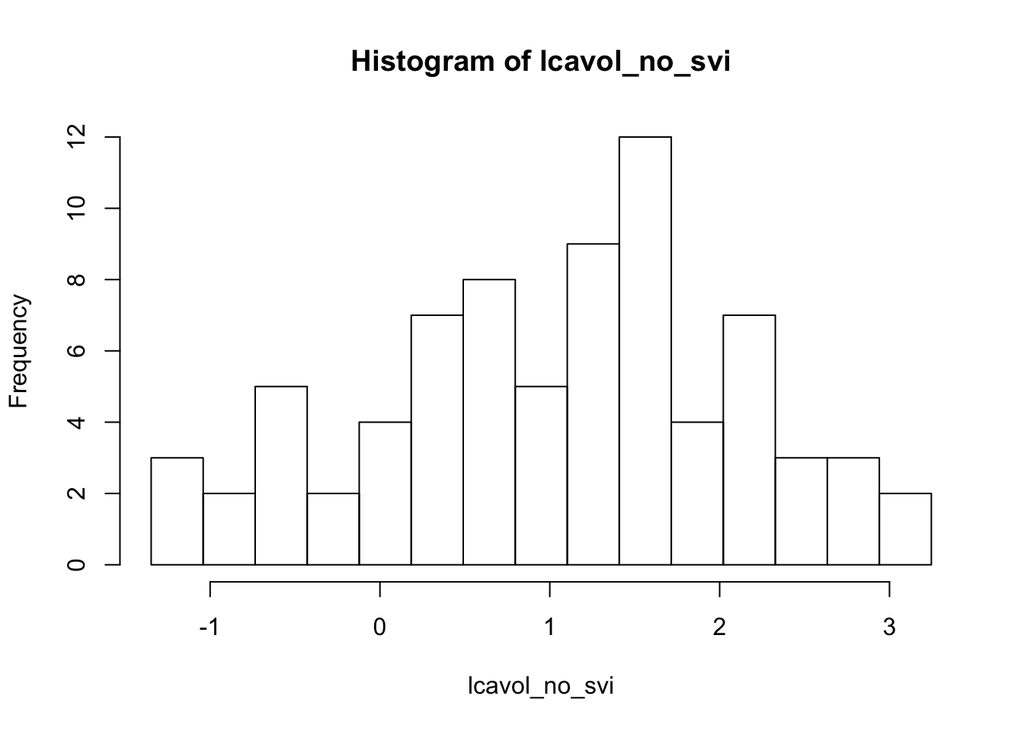

```r
no_svi_hist <- hist(lcavol_no_svi, main = "Histogram of lcavol_no_svi",
                    breaks = breaks_split_no.svi)
```

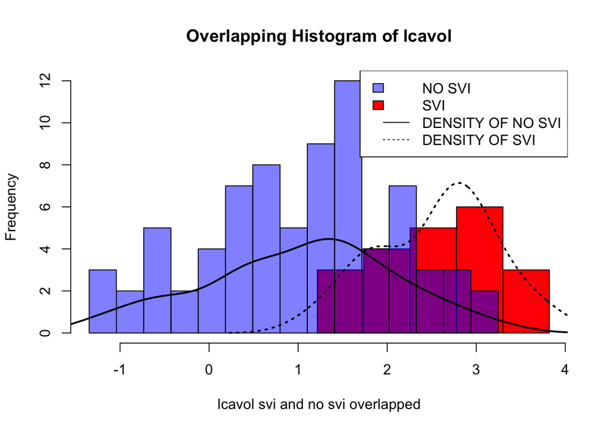

```r
#Overlapping with proper ylim, over the full range of lcavol, with colours
plot(svi_hist, ylim = c(0,max(c(svi_hist$count,no_svi_hist$count))),
     main = "Overlapping Histogram of lcavol",
     xlab = "lcavol svi and no svi overlapped",
     col = "red",
     xlim = range(min(pros.dat$lcavol),max(pros.dat$lcavol)))

plot(no_svi_hist, ylim = c(0,max(c(svi_hist$count,no_svi_hist$count))),
     col = rgb(red = 0, blue = 1, green = 0, alpha = 0.5),
     xlim = range(min(pros.dat$lcavol),max(pros.dat$lcavol)),
     add = TRUE)

#Density vector calculaiton
density_svi <- density(lcavol_svi)
density_no.svi <- density(lcavol_no_svi)
#adjusting y to increase size (based on max of ylim in histogram)
density_svi$y = density_svi$y * 12 #Not needed, but done for visual purposes
density_no.svi$y = density_no.svi$y * 12 #Not needed, but done for visual purposes

#drawing the density lines
lines(density_svi, lwd = 2, lty = "dotted")
lines(density_no.svi, lwd = 2)

#Legends
legend("topright", c("NO SVI", "SVI", "DENSITY OF NO SVI", "DENSITY OF SVI"),
       fill=c(rgb(red = 0, blue = 1, green = 0, alpha = 0.5), "red", NA, NA),
       border = c("black", "black", NA, NA),
       lty = c(NA, NA, "solid", "dotted"))
```

**1e (5 pts)** Now, use `lapply()` to perform t-tests for each variable in the data set, between SVI and non-SVI groups. To be precise, you will perform a t-test for each variable excluding the SVI variable itself for a total of 8 t-tests. For convenience, we’ve defined a function `t.test.by.ind()` below, which takes a numeric variable `x`, and then an indicator variable `ind` (of 0s and 1s) that defines the groups. Run this function on the columns of `pros.dat`, excluding the SVI column itself, and save the result as `tests`. Determine what kind of data structure `tests` is, and print it to the console.

```r
t.test.by.ind = function(x, ind) {
  stopifnot(all(ind %in% c(0, 1)))
  return(t.test(x[ind == 0], x[ind == 1]))
}
#T-Test lapply() method
tests <- lapply(pros.dat[,-5],FUN = t.test.by.ind, ind = pros.dat$svi)

#checking data structure type
datatype_tests <- class(tests)

#Printing
print(datatype_tests)
```

```
## [1] "list"
```

```
It is a list type variable
```

**1f (6 pts)** Take a look at the first element of the `tests` object you created in the last question. Display to the console what kind of object is it, and extract and display its p-value. Using what you have learned, extract the p-values from `tests`. Use an apply function, in a single line of code.

```r
#Taking a look
tests[[1]]
```

```
##
##  Welch Two Sample t-test
##
## data:  x[ind == 0] and x[ind == 1]
## t = -8.0351, df = 51.172, p-value = 1.251e-10
## alternative hypothesis: true difference in means is not equal to 0
## 95 percent confidence interval:
##  -1.917326 -1.150810
## sample estimates:
## mean of x mean of y
##  1.017892  2.551959
```

```r
#Type of object
class(tests[[1]]) #It is of type Hypothesis test
```

```
## [1] "htest"
```

```r
#Extracting and displaying P value
lcavol_p_value <- tests$lcavol$p.value
print(lcavol_p_value)
```

```
## [1] 1.25104e-10
```

```r
#Extracting all p-values using apply()
lapply(tests, FUN = function(x) return(x$p.value))
```

```
## $lcavol
## [1] 1.25104e-10
##
## $lweight
## [1] 0.07472088
##
## $age
## [1] 0.2770533
##
## $lbph
## [1] 0.3834772
##
## $lcp
## [1] 4.579752e-10
##
## $gleason
## [1] 0.0008816293
##
## $pgg45
## [1] 2.482255e-05
##
## $lpsa
## [1] 7.879066e-08
```

# Rio Olympics data set

Now we’re going to examine data from the 2016 Summer Olympics in Rio de Janeiro, taken from https://github.com/flother/rio2016 (itself put together by scraping the official Summer Olympics website for information about the athletes). Download the `rio.csv` file from the Finale module on the course website. The following reads in the data and stores it as `rio`.

**Note that all nonnumeric columns are factor variables**. Recall that factors are stored internally as integers. If `x` is a factor variable, you can get the level names for each `x` using `levels(x)`.

In the following questions, when it asks you **to write a sentence**, for full credit write it **programmatically** using the appropriate text functions. That is, your `R` code should generates the sentence with the correct values, even if the data changed.

```r
rio = read.csv("rio.csv")
```

**2a (4 pts)** What kind of object is `rio`. Display its dimensions and columns names. What does each row represent? Determine if there is any missing data? If there is, how many **rows** contain missing data?

```r
#kind of object
class(rio)
```

```
## [1] "data.frame"
```

```r
#Dimension and Column Names
dim(rio)
```

```
## [1] 11538    12
```

```r
names(rio)
```

```
##  [1] "id"            "name"          "nationality"   "sex"
##  [5] "date_of_birth" "height"        "weight"        "sport"
##  [9] "gold"          "silver"        "bronze"        "info"
```

```r
#Each row is an athlete and his attributes, for example
rio[11,]
```

```
##           id        name nationality  sex date_of_birth height weight     sport
## 11 343694681 Abadi Hadis         ETH male    1997-11-06    1.7     63 athletics
##    gold silver bronze info
## 11    0      0      0
```

```r
#Missing data check
missing.rows <- sum(apply(rio, MARGIN = 1, function(x) any(is.na(x))))

#Yes, there are missing data
paste("There are",missing.rows,"rows with missing data")
```

```
## [1] "There are 680 rows with missing data"
```

```
rio is a data.frame object
Each row is an athlete in rio olympics
Yes there is missing data
```

**2b (6 pts)** Use `rio` to answer the following questions. Write a sentence to the console for each answer. How many athletes competed in the 2016 Summer Olympics? How many countries were represented? What were these countries, and how many athletes competed for each one? Which country brought the most athletes, and how many was this?

```r
#How many athletes?
paste("There were", as.character(nrow(rio)), "athletes in 2016 olympics" )
```

```
## [1] "There were 11538 athletes in 2016 olympics"
```

```r
#How many countries?
paste("They represented", length(levels(rio$nationality)), "countries!")
```

```
## [1] "They represented 207 countries!"
```

```r
#What were the contries?
paste(c("These countries are as follows",levels(rio$nationality)),collapse = ", ")
```

[output not shown]

```r
#How many per country
athletes.by.region <- split(rio, f = rio["nationality"])
paste(names(lapply(athletes.by.region, FUN = nrow)),"brought",
      lapply(athletes.by.region, FUN = nrow),"athletes", collapse = ", ")
```

[output not shown]

```r
#country with the most athletes and the number
paste(names(which.max(lapply(athletes.by.region, FUN = nrow))),"brought the most number with",
      lapply(athletes.by.region, FUN = nrow)[which.max(lapply(athletes.by.region, FUN = nrow))],
      "athletes")
```

```
## [1] "USA brought the most number with 567 athletes"
```

**2c (2 pts)** In a sentence, display an answer to the following question. How many medals of each type—gold, silver, bronze—were awarded at this Olympics?

```r
paste("There were",paste(colSums(rio[c("gold","silver","bronze")]),
      names(colSums(rio[c("gold","silver","bronze")])),collapse = ","),"medals awarded")
```

```
## [1] "There were 666 gold,655 silver,704 bronze medals awarded"
```

**2d (5 pts)** Create a column called `total` that adds the number of gold, silver, and bronze medals for each athlete, and add this column to `rio`. Which athlete had the most number of medals and how many was this? Gold medals? Silver medals? In the case of ties, here, display all the relevant athletes.

```r
#Column Creation
total = rio$gold + rio$silver + rio$bronze
rio$total <- total

#One with the most medals
most_medals <- lapply(rio, function(x) x[rio$total == max(rio$total)])
print(paste(most_medals$name,"has the most medals with",most_medals$gold,
            "gold medal(s),",most_medals$silver,"silver medal(s) and",
            most_medals$bronze,"bronze medal(s)"), max.levels = 0)
```

```
## [1] "Michael Phelps has the most medals with 5 gold medal(s), 1 silver medal(s) and 0 bronze medal(s)"
```

```r
#Will work if more than one person has the most number of medals.
#(test with rio$total == 4 in the test condition. )
```

**2e (5 pts)** Using `tapply()`, calculate the total medal count for each country. Save the result as `total.by.nat`, and print it to the console. For each of the following questions, print a statement that states the answer. Which country had the most number of medals, and how many was this? How many countries had zero medals?

```r
#Medal count by country using tapply()
total.by.nat <- tapply(rio$total, rio$nationality, sum)
print(total.by.nat)
```

```
## AFG ALB ALG AND ANG ANT ARG ARM ARU ASA AUS AUT AZE BAH BAN BAR BDI BEL BEN BER
##   0   0   2   0   0   0  22   4   0   0  82   2  18   6   0   0   1  21   0   0
## BHU BIH BIZ BLR BOL BOT BRA BRN BRU BUL BUR CAF CAM CAN CAY CGO CHA CHI CHN CIV
##   0   0   0  12   0   0  51   2   0   7   0   0   0  69   0   0   0   0 113   2
## CMR COD COK COL COM CPV CRC CRO CUB CYP CZE DEN DJI DMA DOM ECU EGY ERI ESA ESP
##   0   0   0   8   0   0   0  24  11   0  15  41   0   0   1   0   3   0   0  45
## EST ETH FIJ FIN FRA FSM GAB GAM GBR GBS GEO GEQ GER GHA GRE GRN GUA GUI GUM GUY
##   4   8  13   1  95   0   0   0 145   0   7   0 160   0   7   1   0   0   0   0
## HAI HKG HON HUN INA IND IOA IRI IRL IRQ ISL ISR ISV ITA IVB JAM JOR JPN KAZ KEN
##   0   0   0  22   4   2   2   8   3   0   0   2   0  72   0  30   1  65  17  13
## KGZ KIR KOR KOS KSA LAO LAT LBA LBR LCA LES LIB LIE LTU LUX MAD MAR MAS MAW MDA
##   0   0  26   1   0   0   0   0   0   0   0   0   0   7   0   0   1   8   0   1
## MDV MEX MGL MHL MKD MLI MLT MNE MON MOZ MRI MTN MYA NAM NCA NED NEP NGR NIG NOR
##   0   5   2   0   0   0   0   0   0   0   0   0   0   0   0  47   0  18   1  19
## NRU NZL OMA PAK PAN PAR PER PHI PLE PLW PNG POL POR PRK PUR QAT ROT ROU RSA RUS
##   0  36   0   0   0   0   0   1   0   0   0  16   1   7   1   1   0  17  23 115
## RWA SAM SEN SEY SIN SKN SLE SLO SMR SOL SOM SRB SRI SSD STP SUD SUI SUR SVK SWE
##   0   0   0   0   1   0   0   4   0   0   0  53   0   0   0   0  11   0   8  28
## SWZ SYR TAN TGA THA TJK TKM TLS TOG TPE TTO TUN TUR TUV UAE UGA UKR URU USA UZB
##   0   0   0   0   6   1   0   0   0   5   1   3   8   0   1   0  15   0 264  13
## VAN VEN VIE VIN YEM ZAM ZIM
##   0   3   2   0   0   0   0
```

```r
#Country with most medals
print(paste(names(which.max(total.by.nat)),"has the most, with",max(total.by.nat),
            "medals"))
```

```
## [1] "USA has the most, with 264 medals"
```

```r
#Countries with zero medals
print(paste(sum(total.by.nat == 0),"countries have zero medals."))
```

```
## [1] "120 countries have zero medals."
```

**2f (5 pts)** Among the countries that had zero medals, which had the most athletes, and how many athletes was this?

```r
#Countries with zero medals
zero <- total.by.nat[total.by.nat == 0]

#no of athletes per nation
athletes.in.region <- lapply(athletes.by.region, FUN = nrow)

#No of athletes in zero nations
zero_athletes <- athletes.in.region[names(zero)]

#Final Answer
print(paste(names(which.max(zero_athletes)),"has the most, with",
            zero_athletes[which.max(zero_athletes)],
            "athletes and no medals"))
```

```
## [1] "CHI has the most, with 42 athletes and no medals"
```

# Young and old by sport

**3a (6 pts)** The variable `date_of_birth` contains strings of the date of birth of each athlete. Use text processing commands to extract the year of birth, and create a new numeric variable called `age`, equal to 2016 - (the year of birth). (Here we’re ignoring days and months for simplicity.) Add the `age` variable to the `rio` data frame. Who is the oldest athlete, and how old is he/she? Who is the youngest athlete, and how old is he/she? In the case of ties, here, display all the relevant athletes.

```r
#Age column
age = strsplit(as.character(rio$date_of_birth),"-")
age = sapply(age, function(x) 2016 - as.integer(x[1]))
rio$age = age

#oldest athlete
paste(c("The oldest athlete(s) are",paste(as.character(rio$name[rio$age == max(rio$age)]),collapse = ", "),"aged",
        max(rio$age)), collapse = " ")
```

```
## [1] "The oldest athlete(s) are Julie Brougham, Mary Hanna aged 62"
```

```r
#Youngest Athlete
paste(c("The youngest athlete(s) are",paste(as.character(rio$name[rio$age == min(rio$age)]),collapse = ", "),"aged",
        min(rio$age)), collapse = " ")
```

```
## [1] "The youngest athlete(s) are Ana Iulia Dascal, Darya Semyonova, Fatima Alkaramova, Gaurika Singh, Kaya Adwoa Forson, Siri Arun Budcharern, Thint Myaat, Yanhan Ai aged 14"
```

**3b (4 pts)** Answer the same questions as in the last part, but now only among athletes who won a medal.

```r
#athletes df with medals
medal_athletes = rio[which(rio$total != 0),]

#oldest athlete with medals
paste(c("The oldest athlete(s) with medals are/is",
        paste(as.character(medal_athletes$name[medal_athletes$age == max(medal_athletes$age)]),
        collapse = ", "),"aged",
        max(medal_athletes$age)), collapse = " ")
```

```
## [1] "The oldest athlete(s) with medals are/is Nick Skelton aged 59"
```

```r
#youngest athlete with medals
paste(c("The youngest athlete(s) with medals are/is",
        paste(as.character(medal_athletes$name[medal_athletes$age == min(medal_athletes$age)]),
        collapse = ", "),"aged",
        min(medal_athletes$age)), collapse = " ")
```

```
## [1] "The youngest athlete(s) with medals are/is Qian Ren aged 15"
```

**3c (5 pts)** Using `split()` and `sapply()` find the number of participants in each sport and the number of gold medals given out for each sport.

```r
print("Number of participants in each sport :-")
```

```
## [1] "Number of participants in each sport :-"
```

```r
#Number of participants for each sport
sapply(split(rio, rio$sport), FUN = nrow)
```

```
##          aquatics           archery         athletics         badminton
##              1445               128              2363               172
##        basketball            boxing             canoe           cycling
##               288               286               331               525
##        equestrian           fencing          football              golf
##               222               246               611               120
##        gymnastics          handball            hockey              judo
##               324               363               432               392
## modern pentathlon            rowing      rugby sevens           sailing
##                72               547               300               380
##          shooting      table tennis         taekwondo            tennis
##               390               172               128               196
##         triathlon        volleyball     weightlifting         wrestling
##               110               384               258               353
```

```r
print("Number of Gold Medals in each sport :-")
```

```
## [1] "Number of Gold Medals in each sport :-"
```

```r
#number of gold medals
sapply(split(rio, rio$sport), function(x) sum(x$gold))
```

```
##          aquatics           archery         athletics         badminton
##               120                 8                66                 8
##        basketball            boxing             canoe           cycling
##                24                13                27                27
##        equestrian           fencing          football              golf
##                15                21                36                 2
##        gymnastics          handball            hockey              judo
##                30                29                34                14
## modern pentathlon            rowing      rugby sevens           sailing
##                 2                48                25                15
##          shooting      table tennis         taekwondo            tennis
##                15                 8                 8                 8
##         triathlon        volleyball     weightlifting         wrestling
##                 2                28                15                18
```

**3d (5 pts)** How old are the youngest and oldest athletes for each sport? Your answer should be a matrix that has one row for each sport, and two columns that display the ages of the youngest and oldest athletes in that sport. The first 3 rows should look like this:

```
                  Youngest Oldest
aquatics               14     41
archery                17     44
athletics              16     47
```

```r
#oldest athlete age by sport
oldest_athletes <- tapply(rio$age, rio$sport, max)

#youngest athlete age by sport
youngest_athletes <- tapply(rio$age, rio$sport, min)

#Matrix
cbind(Youngest = youngest_athletes,Oldest = oldest_athletes)
```

```
##                   Youngest Oldest
## aquatics                14     41
## archery                 17     44
## athletics               16     47
## badminton               19     40
## basketball              20     39
## boxing                  18     37
## canoe                   18     49
## cycling                 18     45
## equestrian              18     62
## fencing                 16     42
## football                16     41
## golf                    18     47
## gymnastics              16     41
## handball                19     44
## hockey                  18     37
## judo                    19     39
## modern pentathlon       17     37
## rowing                  18     57
## rugby sevens            18     36
## sailing                 17     55
## shooting                16     56
## table tennis            15     54
## taekwondo               17     38
## tennis                  19     44
## triathlon               19     38
## volleyball              18     41
## weightlifting           16     41
## wrestling               18     38
```

# Text and functions

Now we will return to analyzing a text word file by writing two versions of a function to create a table of word frequencies. Download the `clinton.txt` file from Week 6 of the canvas website.

**4a (8 pts)** Create a function named `create_word_table()` that returns a table of words given the name of a text file as input. Your function should use `readLines()` to read the file, split the text at every line and single space into words (all lower case), remove empty words, and finally use `table()` to return a table of word frequencies. Be sure to provide comments before the function that describes your function and lists its inputs and output.

```r
#create_word_table()
# returns a table of words given the name of a text file as input.
# Parametrs : file - file name to read.
# Returns : table
create_word_table <- function(file) {
  #Reading the file and extracting the lines
  file.lines = readLines(file)
  #Collapsing all lines to remove empty lines
  file.lines.combined <- paste(file.lines, collapse = " ")
  #Extracting lowercased words without space or space with puctuations
  file.words <- unlist(strsplit(tolower(file.lines.combined),
                split = "[[:space:]]|[[:punct:]]+[[:space:]]"))
  #Removing empty words
  file.words <- file.words[which(nchar(file.words) != 0)]
  #Removing words with "\"
  file.words <- ifelse(substr(file.words,1,1) == '\"',
                substr(file.words,2,nchar(file.words)),file.words)
  #Returning table of the cleaned words
  return(table(file.words))
}

#Testing Function
word.table <- create_word_table("clinton.txt")
```

**4b (4 pts)** Call your function on the `clinton.txt` word file and show the first 30 elements returned. What kind of object is the return table. How many words did clinton use just once? Twice? At least 10 times? More than 100 times?

```r
#Calling Function
word.table <- create_word_table("clinton.txt")

#First 30 elements
word.table[1:30]
```

```
## file.words
##           1          10         100         112          12          13
##           1           1           1           1           1           1
##          14          15         161         240         2nd          40
##           1           1           1           1           1           1
##          45          50         500          60  7-year-old      70-odd
##           1           1           1           1           1           1
##           8          80        9/11          90           a   abandoned
##           1           1           2           1         106           1
##        able       about      abroad      accept      access accountable
##           1          11           1           1           1           1
```

```r
#kind of object
class(word.table[1:30])
```

```
## [1] "table"
```

```r
#Words used just once
paste("Clinton used",sum(word.table == 1),"words just once")
```

```
## [1] "Clinton used 820 words just once"
```

```r
#Words used twice
paste("Clinton used",sum(word.table == 2),"words twice")
```

```
## [1] "Clinton used 200 words twice"
```

```r
#Words used atleast 10 times
paste("Clinton used",sum(word.table >= 10),"words atleast 10 times")
```

```
## [1] "Clinton used 101 words atleast 10 times"
```

```r
#Words used more than 100 times
paste("Clinton used",sum(word.table > 100),"words more than 100 times")
```

```
## [1] "Clinton used 4 words more than 100 times"
```

**4c (8 pts)** Improve your function by adding `split` as an argument, with a default value that splits at white spaces and at punctuation followed by white spaces. Add logical arguments with default values that indicate whether or not to sort the word table (sort in decreasing order) or whether or not to plot the sorted word table. The plot should always be sorted regardless of the value of the sort argument. Plot the sorted word counts (not the words) on the y-axis versus the ranks (indexes of the counts) on the x-axis. The plot type should be a line and have labels as appropriate. Update your comments for the new inputs and their default value. Call your function on the `clinton.txt` word file with the sort and plot arguments set to true (which need not be your default values) and show the first 20 elements and last 10 elements returned.

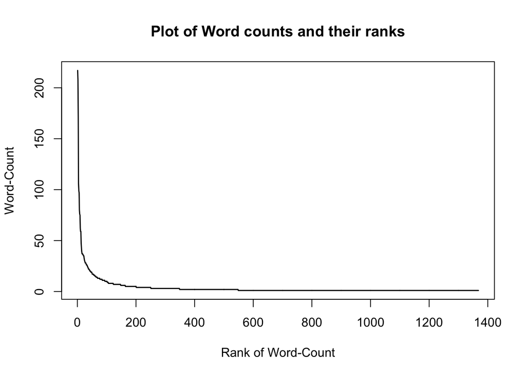

```r
#create_word_table() improved
# returns a table of words given the name of a text file as input.
# Parametrs : file - file name to read. split - character to split at. default value
#             is "[[:space:]]|[[:punct:]]+[[:space:]]"
#             sort - whether soring is needed (default = FALSE),
#             plot - whether plotting is needed.(default = FALSE)
# Returns : table - table of words
create_word_table <- function(file, split = "[[:space:]]|[[:punct:]]+[[:space:]]",
                              sort = FALSE, plot = FALSE) {
  #Reading the file and extracting the lines
  file.lines = readLines(file)
  #Collapsing all lines to remove empty lines
  file.lines.combined <- paste(file.lines, collapse = " ")
  #Extracting lowercased words without space or space with puctuations
  file.words <- unlist(strsplit(tolower(file.lines.combined),
                split = split))
  #Removing empty words
  file.words <- file.words[which(nchar(file.words) != 0)]
  #Removing words with "\"
  file.words <- ifelse(substr(file.words,1,1) == '\"',
                substr(file.words,2,nchar(file.words)),file.words)

  table = table(file.words)
  #plotting is plotting is true
  if(plot == TRUE) {
    #using sorted table for plot
    plot_table <- sort(table, decreasing = TRUE)
    #Making an index vector to get corresponding rank
    x_axis <- 1:length(plot_table)

    #plotting
    plot(x_axis, as.vector(plot_table), type = 'l', xlab = "Rank of Word-Count",
         ylab = "Word-Count", main = "Plot of Word counts and their ranks",
         lwd = 1.5)
  }
  #Sorting if sorting is true
  if(sort == TRUE) {
    return(sort(table, decreasing = TRUE))
  }
  #Returning table of the cleaned words
  return(table)
}

#Calling function
result_table = create_word_table("clinton.txt", sort = TRUE, plot = TRUE)
```

```r
#Frist 20 and last 10 elements
head(result_table, 20)
```

```
## file.words
##    and    the     to      a     we     of    you     in    our   that    for
##    217    208    173    106     99     97     80     76     75     62     59
##      i     it     is     he   from people   will    are   with
##     59     47     43     39     37     37     37     36     36
```

```r
tail(result_table, 10)
```

```
## file.words
##        worst     wouldn't        wreck        write      written year-by-year
##            1            1            1            1            1            1
##         york       you'll     yourself          zip
##            1            1            1            1
```